# Data Report: An EEG experiment on Speech-in-Noise Comprehension

Pilot EEG study on using a sentence matrix comprehension task with noise-vocoded speech and speech in speech-shaped noise https://github.com/Neuroling/SPINCO_SINEEG

Authors

Affiliations

Gorka Fraga-Gonzalez

Neurolinguistics group, University of Zurich

Samuel Mueller

Neurolinguistics group, University of Zurich

Alexis Hervais-Adelman

Neurolinguistics group, University of Zurich

Department of fundamental neurosciences, University of Geneva

Published

February 11, 2024

# 1 Introduction

Hearing loss is becoming an increasingly common complaint, not solely due to aging populations, but also as a result of increasing incidence of noise-induced hearing loss in younger individuals Niskar et al. (2001) and Shargorodsky et al. (2010). One of the major consequences is reduced speech-comprehension ability, especially in acoustically challenging conditions such as in reverberant or noisy environments. Individual differences in (dis)satisfaction with both hearing aids and cochlear implants calls for more investigation on interventions that could enhance speech comprehension abilities by exploiting existing cognitive mechanisms. To this end, this project aims at gaining fundamental knowledge on the neurocognitive basis of speech comprehension in acoustically challenging situations.

This pilot study is aimed at specifying targets and experimental design for subsequent studies focused on potential neurofeedback interventions

**Important note on the links to scripts on Github**

This is ongoing work and contains links to scripts in the project’s Github repository. Here we often use the URL of a specific folder in the scripts’ repository, instead of using the Github’s permalink to a script, which would link to the script version at the time of writing this report. This was done because it is possible that some scripts changed or were debugged after this report. Based on the description, filenames and comments in the code, it should be easy to identify which scripts performed the reported actions. In other instance, like for stimuli generation and presentation of the experiment, we use the permalink to point at the script version used at the time of the experiments.

👁️! If you find any broken link or cannot find a script described in this report, please contact the authors

# 2 Methods

## 2.1 Participants and procedures

We recruited 15 adult participants using a mailing list of the Faculty of Psychology (University of Zurich) and flyers. Inclusion criteria were: age 18-35 years, normmal hearing without hearing aids, normal vision (corrections allowed), German as first language, right-handed. Exclusion criteria were being fuent in more than two languages, having hearing aids or history of hearing impairments or having any psychological or psychiatric condition that may impede adequate task performance (e.g., attentional problems, speech comprehension issues). All participants signed an inform consent form before participation with included a 60 CHF reward for participation. The study was approved by the ethics commision of the canton of Zurich.

After completing the questionnaires participants were informed about the specific content of the session. Electrode placement and signal check took approximately between 20 and 40 minutes. Then a few example trials were presented before starting the session consisting of: a 4 minutes resting state recording with eyes closed, the main task (with 4 blocks of approximately 15 minuntes duration each) and finally, another 4 minutes of eyes closed resting state.

## 2.2 Resting-state recordings

The resting-state recordings before and after the task were identical. Subjects were instructed to close their eyes and remain still for 4 minutes. The start and end of the 4 minutes block was indicated by a beep sound (1-second long).

## 2.3 Main Task

### 2.3.1 Trial design

We used a version of the Coordinate Response Measure (CRM) task used in Brungart (2001). In the task, participants listen to different versions of a sentence with a fixed structure and three words that change in every trial. There are 4 possible alternatives for each of the targets, thus there are 64 possible variations of the sentences. The task was originally designed to investigate intelligibility of speech commands (in a military context) in audio transmissions with various types of background competition. The German sentence used in this study was: “*Vorsicht* [call sign], *geh sofort zum* [color] *Feld von der Spalte*[number]” (Translated with a small variation from the original article in English: “*Ready [call sign] go to [color][number] now*”). The 4 possible call sign items were: Adler, Drossel, Tiger or Kröte (eagle, thrush, tiger or toad). The possible colors were gelben, gruenen, roten, weissen (yellow, green, red or white). The numbers were Ein, Zwei, Drei or Vier (one to four).

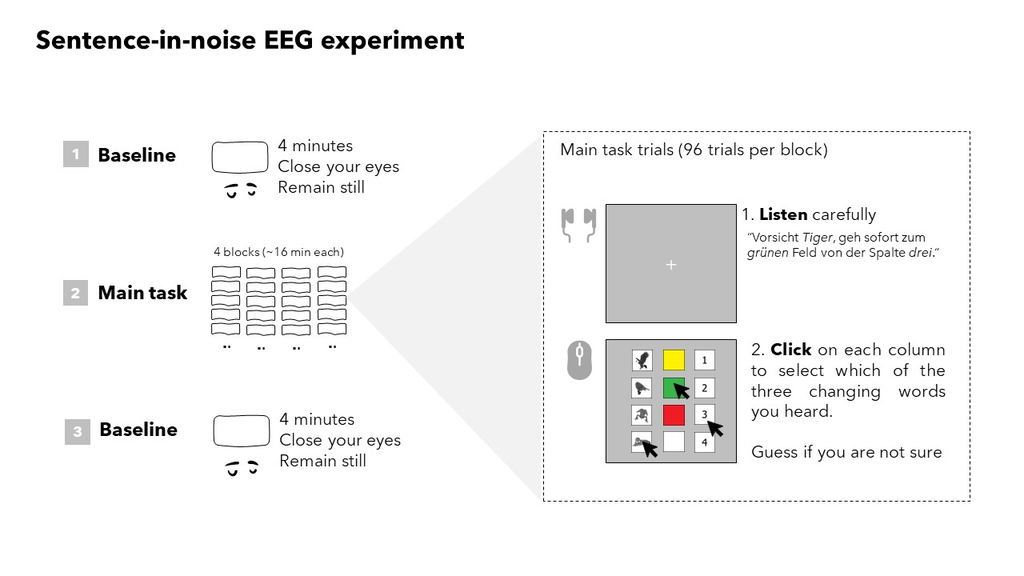

Figure 1. Overview of the experimental session

In each trial the sentences were aurally presented and a fixation cross was shown in the center of the screen. After playing the sentence, an array of 4 x 3 was shown with drawings representing the target items, the array had always in the same order and columns 1-3 represented targets 1-3 in the same order as they appeared in the sentence, that is, first the column with call signs, then colors and then numbers. Participants had to click with the mouse on the picture representing the item they heard in each of the columns before moving on to the next trial. The trials were response-terminated, but there was a response time limit of 10 seconds before moving on to the next trial. In the example trials, presented with 3 different levels of auditory difficulty the researchers conducting the experiment ensured that participants understood that they should click on each of the three columns in all trials, even if they were not sure what item they heard.

### 2.3.2 Blocks design

The sentences were presented in blocks of two audio manipulation conditions: noise vocoded (NV) or with a background speech-shaped noise (SSN) and there were three possible levels of difficulty. Half of the sentences were synthesized with a female voice and half with a male voice. The *Stimuli* section provides more details on these manipulations.

### 2.3.3 Stimuli

#### Speech generation

We used the [Google Cloud Text-to-speech API](https://cloud.google.com/text-to-speech/) to generate the 64 possible variations of our sentence in a female and male speaker voice. Each sentence was output in a separate .wav file with 48KHz sampling rate. After trying several of the freely available voices we chose the [neural2 voices](https://cloud.google.com/text-to-speech/docs/voice-types#neural2_voices) ‘de-DE-Neural2-D’ and ‘de-DE-Neural2-F’ for male and female speech, respective, as they sounded more natural (this was verified by native speakers). We used a Python script to communicate with the text-to-speech API (see  
[sentence generation script](https://github.com/Neuroling/SPINCO_SINEEG/blob/9d0c5f89611f521f7e93dd9b2087706180e1036d/Gen_stimuli/Gen_speech/TTS_sentenceGenerator.py) in our project repository)

#### Noise vocoding

With the noise vocoding technique we manipulate and degrade spectral information of speech stimuli, while preserving slow varying temporal cues. This approach is used as a crude simulation of the loss of frequency information experienced by individual with cochlear implants. In short, it consists of filtering the signal into a range of frequency bands, extracting the smoothed amplitude profile of each band, using this profile as modulating wave of some noise (typically white noise) and then reconstructing the signal. The less frequency bands we use the less channels we have to reconstruct the signal and the less intelligible the output will be (16 channels yields intelligible speech, 3 practically non-intelligible). A relevant parameter is how the frequency bands are spaced, e.g., they can be spaced linearly, logarithmically or following other functions. The Greenwood frequency-position function (see Greenwood (1990) for a review) is used often to estimate how the frequencies are represented in cochlear implant electrodes. It correlates the position of hair cells in the inner ear to the frequencies that stimulate their auditory neurons.

In our study we used the vocoding approach described in Aller et al. (2022), and modified from Zoefel, Gilbert, and Davis (2023). The scripts are at the [Gen_speech_noise folder] (https://github.com/Neuroling/SPINCO_SINEEG/tree/main/Gen_stimuli/Gen_speech_noise)of our repository. A wrapper [*run* script](https://github.com/Neuroling/SPINCO_SINEEG/blob/9d0c5f89611f521f7e93dd9b2087706180e1036d/Gen_stimuli/Gen_speech_noise/Run_vocoder_aller.m) is used to call the associated functions for this manipulation. The main function used was vocode_aller.m.

In the approach of Aller et al. (2022) the signal was filtered into 16 logarithmically-spaced frequency bands. Then the envelope (env) of each frequency band (b) was multiplied by a proportion (p) of the broadband envelope: envfinal(b)=env(b)*p+env(broadband)*(1−p). The proportion ranges from 0 to 1. If p = 1 it is equivalent to applying a 16-channels vocoder (i.e., fully intelligible). Smaller *p* values (e.g., 0.8) lead to different levels of degradation. This approach allows a bit finer tunning of the intelligibility levels than changing the number of channels in the ‘conventional’ vocoding approach. Internal pilot tests in our lab confirmed this advantage for our stimuli.

#### Speech in speech-shaped noise

Another auditory manipulation in this study was embedding the sentences into background noise. This is a frequent acoustically challenging circumstance, for example, when having to undestand someone with the noise of traffic of in the background. As a control in this manipulation, the background noise used was created to have similar spectral properties as speech, that is, we used speech-shaped noise.

The [*runner* script](https://github.com/Neuroling/SPINCO_SINEEG/blob/9d0c5f89611f521f7e93dd9b2087706180e1036d/Gen_stimuli/Gen_speech_noise/Run_speechShapeNoise.m) called an [in-house function](https://github.com/Neuroling/SPINCO_SINEEG/blob/9d0c5f89611f521f7e93dd9b2087706180e1036d/Gen_stimuli/Gen_speech_noise/functions/speechshapednoise.m) to filter white noise with the long-term average speech spectrum (LTASS) derived from the signal, which was the concatenated sentences (filtered wiht a 70 to 5000 Hz Butterworth filter, see scripts for details). The LTASS calculation used a function from [SoundZone_Tools](https://github.com/JacobD10/SoundZone_Tools/archive/master.zip). After generating the speech-shaped noise from the concatenated sentence, chunks of noise selected at random from the concatenated signal, were added as background to the sentence, with 0.5 seconds in and out ramps.

## 2.4 EEG

### 2.4.1 Signal acquisition

The EEG recordings were conducted using the Biosemi Active Two MK2hS-System with a sampling rate of 2048 Hz. We used 64 scalp electrodes positioned according to the 10-20 system. In addition, six external Flat-Type Active electrodes were used: four electrodes for recording the vertical and horizontal electro-oculogram (EOG) and two electrodes were placed at mastoids for off-line reference. The Biosemi system uses two additional electrodes (Common Mode Sense [CMS] and Driven Right Leg [DRL]) creating a feedback loop to replace the conventional ground electrode (see www.biosemi.com/faq/cms&drl.htm for details). The CMS electrode served as online reference. The offset of the electrodes was kept between +20 and -20 µV.

### 2.4.2 Minimal preprocessing of source data into ‘raw’ data

During the experimental session a single file was generated containing the resting-state recordings as well as the main task. The file was in Biosemi’s [bdf](https://www.biosemi.com/faq/file_format.htm) format which is a 24 bits version of the popular [EDF](https://www.edfplus.info) format. The file contains the main task and two resting state recordings (before and after task). The file has an additional channel labeled ‘ergo1’ with the audio output signal (sent also to the headphones) to help correcting for audio delay.

The [first script for importing data](https://github.com/Neuroling/SPINCO_SINEEG/blob/main/Analysis/SiN/EEG/1_source_to_raw/Import_01_importBDF_loadLocs_split.m) performs the following:

- *Event trigger adjustment*. The click’s inserted at the start of the *audio signal* are detected for each trial in the task. The onset of the clicks is used to adjust the event triggers (target word onsets and start/end of the sentence) accounting for any audio output delay
- *Split file* in three datasets: `s001_task-rest-pre.set`, `s001_task-rest-post.set`, `s001_task-sin.set` (event triggers are used to determine the split segments)
- *Load Channel locations*
- *Create Metadata*. This includes`.json` metadata files and `.tsv` channel location and event table files. **NOTE** we add the trial accuracy values into the *event table file*, this values are read from the experimental file (in behavioral folder ‘beh’)

The resulting datasets are considered ‘raw’ for subsequent preprocessing and analysis.

**Why was minimally preprocessed raw saved as .set and not .bdf ?**

The .set format was preferred after finding several issues when exporting to formats as bdf or edf using EEGlab and MNE toolboxes. When the ‘Ergo1’ channel with digital audio recorded was loaded, there were (what appeared to be) sampling errors in the exported bdf or edf from EEGlab (using *writeeg* from Biosig) and EDF with [mne export raw](https://mne.tools/stable/generated/mne.export.export_raw.html).These problems were not present when using the Biosemi Actitools software (however this is not a desired step as it requires manual input in GUI and could not be integrated in the scripts).

### 2.4.3 Preprocessing

#### Main Pipeline (automatic with Automagic)

For our main analysis we opted for a fully automated pipeline implemented with the open-source Matlab toolbox automagic, see (Pedroni, Bahreini, and Langer (2019)). The toolbox is actually a wrapper that runs different functions from EEGlab (Delorme and Makeig (2004)), probably the most widely used open-source software for EEG analysis (also Matlab-based). Automagic facilitates selection of multiple options for data cleaning and artifact rejection available in different plugins for EEGlab. In addition, it provides its own data quality summary measures. We chose Automagic as our main preprocessing approach first to facilitate automation, potentially iterating through different pipeline variations and second, to obtain more *objective* descriptors of data quality, constraining the researchers’ degrees of freedom and facilitating transparency on subsequent decisions and explorations on data quality levels vis-a-vis main analyses results.

### 2.4.4 Ongoing Analysis

## 2.5 Results

### 2.5.1 Behavioral analysis

Gathered table

```python
# Library installations:
#conda install -c plotly plotly
#conda install -c conda-forge itables
# ------------------------------------------------------------------
import sys
import os
import glob
import re
import pandas as pd
import numpy as np
import plotly.express as px
from itables import init_notebook_mode, show
from datetime import date
today = date.today()
#print("Run date:", today)

# File paths
thisScriptDir = os.getcwd()
baseDir = thisScriptDir[:thisScriptDir.find("Scripts")]
dirinput = os.path.join(baseDir + 'Data','SiN','analysis','beh','task-sin')
diroutput = os.path.join(baseDir + 'Data','SiN','analysis','beh','task-sin')

# Find file read data set
fileinput =  [os.path.join(dirinput, f) for f in os.listdir(dirinput) if f.startswith('Gathered_')]
df = pd.read_csv(fileinput[0], index_col=None)

# Relabel noise levels
levelmapping = {'0.6p': '1_easy','0.4p': '2_mid','0.2p': '3_hard','-7db': '1_easy','-9db': '2_mid','-11db': '3_hard'}
df['levels'] = df['levels'].replace(levelmapping)

 #  ---------------
print(' Table read with ' + str(len(df)) + ' rows and ' + str(len(df. columns)) + ' columns')
show(df, scrollY="400px", scrollCollapse=True, paging=False)
```

```
 Table read with 5376 rows and 15 columns
```

[output not shown]